# Methods of Prediction- Speech Emotion Recognition

EmoTech Solutions, a prominent technology firm focusing in emotion-driven solutions, has recently hired me. EmoTech Solutions is a pioneer in the development of cutting-edge technologies that use artificial intelligence and machine learning to comprehend and interpret human emotions. I have been entrusted with an important project to increase EmoTech Solutions' products and transform the way emotions are interpreted and evaluated as a specialist in speech emotion recognition.

The emphasis is on building advanced speech emotion recognition algorithms and systems capable of reliably detecting and analyzing emotions in spoken language. The purpose is to deliver useful insights and actionable data to industries such as customer service, market research, healthcare, entertainment, and others. EmoTech Solutions' goal is to empower enterprises to better customer experiences, personalize services, and increase overall emotional well-being by accurately collecting and comprehending human emotions.

## Importing modules

```python
import pandas as pd
import numpy as np
import os
import seaborn as sns
import matplotlib.pyplot as plt
import librosa
import librosa.display
from IPython.display import Audio
import warnings
warnings.filterwarnings("ignore")
from sklearn.preprocessing import StandardScaler
```

## Loading the dataset

### In this section, I have loaded the 3 datasets.

The datasets are basically audio files, therefore we will make a dataset, that contains the file paths and the respective labels (fear, angry, disgust, neutral, sad, ps, happy).

Since different datasets have different filenames, extracting the labels for each dataset has to be done differntly. I already know what the filenames look like, therefore I have done it directly.

Links to the Datasets

1. TESS: https://www.kaggle.com/datasets/ejlok1/toronto-emotional-speech-set-tess
2. RAVDESS: https://www.kaggle.com/datasets/uwrfkaggler/ravdess-emotional-speech-audio
3. CREMA-D: https://www.kaggle.com/datasets/ejlok1/cremad

The links above clearly explain the file naming convention and the labels and paths can be further extracted like this:

##### 1. TESS_paths and TESS_labels are empty lists that will be filled with the TESS dataset's file directories and labels, respectively.

##### 2. The os.walk() method is used to navigate the directory structure indicated in the path ('/Users/ayushphukan/Downloads/Jupyter Projects/TESS Toronto emotional speech set data'). It loops over all of the directories, subdirectories, and files contained inside the provided root directory.

##### 3. The loop iterates over the file_names list, which holds the names of all the files in the current directory, throughout each iteration of os.walk().

##### 4. The code appends the whole file path to the TESS_paths list for each file using os.path.join(root_dir, file_name).

##### 5. The label is extracted from each file name by the code. It splits the file name on the "*" character and returns the final member of the list (file_name.split("*")[-1]). The label is then divided again on the "." character, and the first member of the resultant list is taken (label_name.split(."")[0]).

##### 6. The retrieved label is changed to lowercase and inserted to the TESS_labels list using the lower() function.

##### 7 . When the loop is ended, the code outputs "Dataset loaded" to signify that the loading procedure is complete.

```python
TESS_paths = []
TESS_labels = []

for root_dir, _, file_names in os.walk('/Users/ayushphukan/Downloads/Jupyter Projects/TESS Toronto emotional speech set data'):
    for file_name in file_names:
        TESS_paths.append(os.path.join(root_dir, file_name))
        print(file_name)
        label_name = file_name.split("_")[-1]
        label_name = label_name.split(".")[0]
        TESS_labels.append(label_name.lower())

print("Dataset loaded")
```

```
YAF_date_disgust.wav
YAF_rag_disgust.wav
YAF_raise_disgust.wav
YAF_ditch_disgust.wav
YAF_door_disgust.wav
YAF_note_disgust.wav
YAF_pearl_disgust.wav
YAF_search_disgust.wav
YAF_late_disgust.wav
YAF_peg_disgust.wav
YAF_ring_disgust.wav
YAF_tool_disgust.wav
YAF_puff_disgust.wav
YAF_dip_disgust.wav
YAF_walk_disgust.wav
YAF_lot_disgust.wav
YAF_knock_disgust.wav
YAF_jug_disgust.wav
YAF_home_disgust.wav
YAF_dab_disgust.wav
YAF_tire_disgust.wav
YAF_road_disgust.wav
YAF_burn_disgust.wav
YAF_make_disgust.wav
YAF_mood_disgust.wav
YAF_mess_disgust.wav
YAF_cab_disgust.wav
YAF_shawl_disgust.wav
YAF_wife_disgust.wav
YAF_chain_disgust.wav
YAF_base_disgust.wav
YAF_judge_disgust.wav
YAF_came_disgust.wav
YAF_rat_disgust.wav
YAF_beg_disgust.wav
YAF_choice_disgust.wav
YAF_hit_disgust.wav
YAF_hole_disgust.wav
YAF_time_disgust.wav
YAF_five_disgust.wav
```

[output cut: 5546 more lines]

```
OAF_dog_sad.wav
OAF_rag_sad.wav
OAF_dip_sad.wav
OAF_rush_sad.wav
OAF_shack_sad.wav
OAF_lean_sad.wav
OAF_join_sad.wav
OAF_rough_sad.wav
OAF_fail_sad.wav
OAF_tool_sad.wav
OAF_goose_sad.wav
OAF_met_sad.wav
OAF_pearl_sad.wav
OAF_rain_sad.wav
Dataset loaded
```

```python
TESS_paths[:2]
```

```
['/Users/ayushphukan/Downloads/Jupyter Projects/TESS Toronto emotional speech set data/YAF_disgust/YAF_date_disgust.wav',
 '/Users/ayushphukan/Downloads/Jupyter Projects/TESS Toronto emotional speech set data/YAF_disgust/YAF_rag_disgust.wav']
```

```python
TESS_labels[:5]
```

```
['disgust', 'disgust', 'disgust', 'disgust', 'disgust']
```

#### A similar method has been used for the other 2 datasets based on their file naming convention

```python
RAVDESS_paths = []
RAVDESS_labels = []

for root_dir, _, file_names in os.walk('/Users/ayushphukan/Downloads/Jupyter Projects/RAVDESS'):
    for file_name in file_names:
        RAVDESS_paths.append(os.path.join(root_dir, file_name))
        print(file_name)
        label_name = file_name.split("-")[2]
        RAVDESS_labels.append(label_name.lower())



print("Dataset loaded")
```

```
03-01-05-01-02-01-16.wav
03-01-06-01-02-02-16.wav
03-01-06-02-01-02-16.wav
03-01-05-02-01-01-16.wav
03-01-07-01-01-01-16.wav
03-01-04-01-01-02-16.wav
03-01-04-02-02-02-16.wav
03-01-07-02-02-01-16.wav
03-01-08-02-02-01-16.wav
03-01-08-01-01-01-16.wav
03-01-03-02-02-02-16.wav
03-01-03-01-01-02-16.wav
03-01-02-02-01-01-16.wav
03-01-01-01-02-02-16.wav
03-01-02-01-02-01-16.wav
03-01-03-02-01-01-16.wav
03-01-03-01-02-01-16.wav
03-01-02-02-02-02-16.wav
03-01-02-01-01-02-16.wav
03-01-01-01-01-01-16.wav
03-01-06-01-01-01-16.wav
03-01-05-01-01-02-16.wav
03-01-05-02-02-02-16.wav
03-01-06-02-02-01-16.wav
03-01-04-01-02-01-16.wav
03-01-07-01-02-02-16.wav
03-01-07-02-01-02-16.wav
03-01-04-02-01-01-16.wav
03-01-08-02-01-02-16.wav
03-01-08-01-02-02-16.wav
03-01-02-01-02-02-16.wav
03-01-01-01-02-01-16.wav
03-01-02-02-01-02-16.wav
03-01-03-01-01-01-16.wav
03-01-03-02-02-01-16.wav
03-01-07-02-02-02-16.wav
03-01-04-02-02-01-16.wav
03-01-04-01-01-01-16.wav
03-01-07-01-01-02-16.wav
03-01-05-02-01-02-16.wav
```

[output cut: 2826 more lines]

```
03-01-08-01-01-01-08.wav
03-01-06-01-02-02-08.wav
03-01-05-01-02-01-08.wav
03-01-05-02-01-01-08.wav
03-01-06-02-01-02-08.wav
03-01-04-01-01-02-08.wav
03-01-07-01-01-01-08.wav
03-01-07-02-02-01-08.wav
03-01-04-02-02-02-08.wav
03-01-03-02-02-02-08.wav
03-01-03-01-01-02-08.wav
03-01-02-02-01-01-08.wav
03-01-02-01-02-01-08.wav
03-01-01-01-02-02-08.wav
Dataset loaded
```

```python
RAVDESS_paths[:2]
```

```
['/Users/ayushphukan/Downloads/Jupyter Projects/RAVDESS/Actor_16/03-01-05-01-02-01-16.wav',
 '/Users/ayushphukan/Downloads/Jupyter Projects/RAVDESS/Actor_16/03-01-06-01-02-02-16.wav']
```

```python
RAVDESS_labels[:5]
```

```
['05', '06', '06', '05', '07']
```

```python
CREMAD_paths = []
CREMAD_labels = []

for root_dir, _, file_names in os.walk('/Users/ayushphukan/Downloads/Jupyter Projects/AudioWAV'):
    for file_name in file_names:
        CREMAD_paths.append(os.path.join(root_dir, file_name))
        print(file_name)
        label_name = file_name.split("_")[2]
        CREMAD_labels.append(label_name.lower())



print("Dataset loaded")
```

```
1022_ITS_ANG_XX.wav
1037_ITS_ANG_XX.wav
1060_ITS_NEU_XX.wav
1075_ITS_NEU_XX.wav
1073_IOM_DIS_XX.wav
1066_IOM_DIS_XX.wav
1078_IWL_SAD_XX.wav
1029_TAI_FEA_XX.wav
1039_IEO_SAD_MD.wav
1008_TAI_HAP_XX.wav
1018_TSI_FEA_XX.wav
1028_IEO_SAD_HI.wav
1039_TSI_HAP_XX.wav
1064_ITS_HAP_XX.wav
1071_ITS_HAP_XX.wav
1045_ITS_FEA_XX.wav
1050_ITS_FEA_XX.wav
1018_IWL_ANG_XX.wav
1059_IEO_ANG_MD.wav
1054_MTI_DIS_XX.wav
1041_MTI_DIS_XX.wav
1048_IEO_ANG_HI.wav
1042_ITS_SAD_XX.wav
1019_TAI_NEU_XX.wav
1057_ITS_SAD_XX.wav
1028_TSI_NEU_XX.wav
1087_IOM_ANG_XX.wav
1039_IEO_HAP_LO.wav
1018_IEO_FEA_LO.wav
1079_DFA_NEU_XX.wav
1063_IWW_DIS_XX.wav
1076_IWW_DIS_XX.wav
1068_WSI_HAP_XX.wav
1049_WSI_FEA_XX.wav
1059_ITH_DIS_XX.wav
1068_DFA_HAP_XX.wav
1049_DFA_FEA_XX.wav
1079_WSI_NEU_XX.wav
1082_IWW_ANG_XX.wav
1061_ITH_NEU_XX.wav
```

[output cut: 7388 more lines]

```
1050_IWW_SAD_XX.wav
1089_DFA_ANG_XX.wav
1079_TIE_SAD_XX.wav
1068_WSI_DIS_XX.wav
1067_IWW_NEU_XX.wav
1078_ITH_FEA_XX.wav
1072_IWW_NEU_XX.wav
1059_ITH_HAP_XX.wav
1068_DFA_DIS_XX.wav
1089_WSI_ANG_XX.wav
1025_IWW_ANG_XX.wav
1030_IWW_ANG_XX.wav
1019_TIE_ANG_XX.wav
1079_IEO_NEU_XX.wav
Dataset loaded
```

```python
CREMAD_paths[:2]
```

```
['/Users/ayushphukan/Downloads/Jupyter Projects/AudioWAV/1022_ITS_ANG_XX.wav',
 '/Users/ayushphukan/Downloads/Jupyter Projects/AudioWAV/1037_ITS_ANG_XX.wav']
```

```python
CREMAD_labels[:5]
```

```
['ang', 'ang', 'neu', 'neu', 'dis']
```

## All Paths and Labels are now loaded

#### Now we need to change the label names to same in all datasets so that we can then merge the 3 datasets together

Therefore, here I have created a function to finf the unique labels present in the dataset

1. unique_list is an empty list that will be populated with unique labels.
2. The code uses a for loop to iterate over each element x in the labels list.
3. Within the loop, the code checks if the current element x is already present in the unique_list using the condition if x not in unique_list.
4. If the element x is not found in the unique_list, it means it is a unique label, and the code appends it to the unique_list using unique_list.append(x).

The second loop simply prints these unique labels.

```python
def lst_unique_finder(labels):
    unique_list=[]
    for x in labels:
        if x not in unique_list:
            unique_list.append(x)

    for x in unique_list:
        print(x)
```

```python
lst_unique_finder(CREMAD_labels)
```

```
ang
neu
dis
sad
fea
hap
```

#### So, we can change the names respectively using a while loop.

1. I've set i=0 initially and a while loop is run till i < the length of the CREMAD_labels list
2. i is being used to basically access the values using the index.
3. Then, the respective changes are made.

```python
i=0

while i < len(CREMAD_labels):

    if CREMAD_labels[i]=='ang':
        CREMAD_labels[i]=CREMAD_labels[i].replace("ang", "angry")

    elif CREMAD_labels[i]=='neu':
        CREMAD_labels[i]=CREMAD_labels[i].replace("neu", "neutral")

    elif CREMAD_labels[i]=='dis':
        CREMAD_labels[i]=CREMAD_labels[i].replace("dis", "disgust")

    elif CREMAD_labels[i]=='fea':
        CREMAD_labels[i]=CREMAD_labels[i].replace("fea", "fear")

    elif CREMAD_labels[i]=='hap':
        CREMAD_labels[i]=CREMAD_labels[i].replace("hap", "happy")

    i=i+1
```

```python
lst_unique_finder(CREMAD_labels)
```

```
angry
neutral
disgust
sad
fear
happy
```

```python
RAVDESS_paths[:2]
```

```
['/Users/ayushphukan/Downloads/Jupyter Projects/RAVDESS/Actor_16/03-01-05-01-02-01-16.wav',
 '/Users/ayushphukan/Downloads/Jupyter Projects/RAVDESS/Actor_16/03-01-06-01-02-02-16.wav']
```

```python
lst_unique_finder(RAVDESS_labels)
```

```
05
06
07
04
08
03
02
01
```

#### Since '02' stands for calm and we do not have that emotion in the rest of the 2 datasets, I would rather remove these files to avoid imbalance in the data.

```python
RAVDESS_labels = [label for label in RAVDESS_labels if label != '02']
```

```python
RAVDESS_paths = [path for path in RAVDESS_paths if path.split('/')[-1].split('-')[2] != '02']
```

#### A similar technique is being used here to make the label names same throughout all datasets.

```python
i=0

while i < len(RAVDESS_labels):

    if RAVDESS_labels[i]=='01':
        RAVDESS_labels[i]=RAVDESS_labels[i].replace("01", "neutral")

    elif RAVDESS_labels[i]=='03':
        RAVDESS_labels[i]=RAVDESS_labels[i].replace("03", "happy")

    elif RAVDESS_labels[i]=='04':
        RAVDESS_labels[i]=RAVDESS_labels[i].replace("04", "sad")

    elif RAVDESS_labels[i]=='05':
        RAVDESS_labels[i]=RAVDESS_labels[i].replace("05", "angry")

    elif RAVDESS_labels[i]=='06':
        RAVDESS_labels[i]=RAVDESS_labels[i].replace("06", "fear")

    elif RAVDESS_labels[i]=='07':
        RAVDESS_labels[i]=RAVDESS_labels[i].replace("07", "disgust")

    elif RAVDESS_labels[i]=='08':
        RAVDESS_labels[i]=RAVDESS_labels[i].replace("08", "surprise")

    i=i+1
```

```python
lst_unique_finder(RAVDESS_labels)
```

```
angry
fear
disgust
sad
surprise
happy
neutral
```

```python
TESS_paths[:2]
```

```
['/Users/ayushphukan/Downloads/Jupyter Projects/TESS Toronto emotional speech set data/YAF_disgust/YAF_date_disgust.wav',
 '/Users/ayushphukan/Downloads/Jupyter Projects/TESS Toronto emotional speech set data/YAF_disgust/YAF_rag_disgust.wav']
```

#### Here 'ps' stands for surprise, so that's the only thing that needs to be changed

```python
lst_unique_finder(TESS_labels)
```

```
disgust
ps
happy
sad
neutral
fear
angry
```

#### Same method used again.

```python
i=0

while i < len(TESS_labels):

    if TESS_labels[i]=='ps':
        TESS_labels[i]=TESS_labels[i].replace("ps", "surprise")

    i=i+1
```

```python
lst_unique_finder(TESS_labels)
```

```
disgust
surprise
happy
sad
neutral
fear
angry
```

### Now that the label names for all the datasets is the same, we can finally merge the three lists by simply using the "+" operand.

First we will add the filepaths Then the file labels. We have to make sure, the order used for both filepaths and labels must be the same.

```python
filepaths= CREMAD_paths + RAVDESS_paths + TESS_paths
file_labels= CREMAD_labels + RAVDESS_labels + TESS_labels
```

```python
len(filepaths)
```

```
15538
```

```python
len(file_labels)
```

```
15538
```

#### The Length of both the lists is same, which means everything is correct till now.

## Creating the dataset

Now lets use these lists to make a dataframe.

```python
df= pd.DataFrame()
df['Speech']= filepaths
df['Label']= file_labels
```

```python
df.head()
```

|  | Speech | Label |
| --- | --- | --- |
| 0 | /Users/ayushphukan/Downloads/Jupyter Projects/... | angry |
| 1 | /Users/ayushphukan/Downloads/Jupyter Projects/... | angry |
| 2 | /Users/ayushphukan/Downloads/Jupyter Projects/... | neutral |
| 3 | /Users/ayushphukan/Downloads/Jupyter Projects/... | neutral |
| 4 | /Users/ayushphukan/Downloads/Jupyter Projects/... | disgust |

##### 1. The function is_audio_file takes a single parameter, file_path, which represents a file's path.

##### 2. The endswith() method is used to determine whether the file_path ends with the string '.wav'. If the string ends with the supplied suffix (in this case,.wav), the endswith() method returns True, otherwise it returns False.

##### 3. The function returns either True or False as the outcome of the endswith() method.

```python
def is_audio_file(file_path):
    return file_path.endswith('.wav')
```

#### Applying this to our "Speech" column which contains the paths.

```python
df = df[df['Speech'].apply(is_audio_file)]
```

```python
df['Label'].value_counts()
```

```
angry       2455
disgust     2455
sad         2455
fear        2455
happy       2455
neutral     2079
surprise    1184
Name: Label, dtype: int64
```

# Working with sound

1. To digitize a sound wave, we must convert the signal into a series of numbers that can be fed into our models. This is accomplished by measuring the amplitude of the sound at regular periods of time. Each of these measurements is referred to as a sample, and the sample rate is the number of samples taken each second and this can be visualised using a spectrum
2. The Spectrum is the set of frequencies that are combined together to produce a signal. The Spectrum plots all of the frequencies that are present in the signal along with the strength or amplitude of each frequency.
3. But there's a problem with spectrums too. Spectrums only help visualise one instance in the entire audio file and the audio/sound changes with time and different frequencies have changes in amplitude over time. To visualise the change over time, Spectrograms are used.

#### A Spectrogram of a signal is a 'picture' of the signal that traces its Spectrum with time. Time is plotted on the x-axis, while frequency is plotted on the y-axis. It's as if we took the Spectrum at various points of time and then merged them all together into a single plot.

#### It employs several colors to represent the amplitude or intensity of each frequency. The higher the energy of the signal, the brighter the hue. Each vertical'slice' of the Spectrogram is effectively the Spectrum of the signal at that point in time, displaying how the signal intensity is divided across all frequencies present in the signal at that point.

1. The waveform is plotted using the librosa.display.waveshow() method, which depicts the amplitude of the audio stream with time.
2. The librosa.stft() function computes the Short-Time Fourier Transform (STFT), a time-frequency representation of an audio stream.
3. The librosa.amplitude_to_db() function transforms the amplitude values of the STFT to decibels, resulting in a more perceptually relevant spectrogram representation.
4. The spectrogram, which visualizes the strength of distinct frequency components over time, is plotted using the librosa.display.specshow() method.

Overall, librosa allows us to extract and display significant properties of audio signals, which aids in the analysis and comprehension of audio data.

##### Also, we have used matplotlib for visualising the audio file and spectrogram.

I have plotted each of the emotions once

```python
def display_wave(data, sampling_rate, title):
    plt.figure(figsize=(10, 4))
    plt.title(title)
    librosa.display.waveshow(data, sr=sampling_rate)
    plt.show()

def display_spectrogram(data, sampling_rate, title):
    transform_stft = librosa.stft(data)


    amplitude_db = librosa.amplitude_to_db(abs(transform_stft))
    plt.figure(figsize=(10, 4))
    plt.title(title)
    librosa.display.specshow(amplitude_db, sr=sampling_rate, x_axis='time', y_axis='hz')
    plt.colorbar()
```

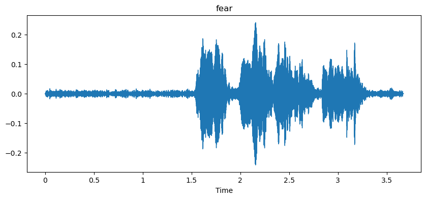

[interactive chart not shown]

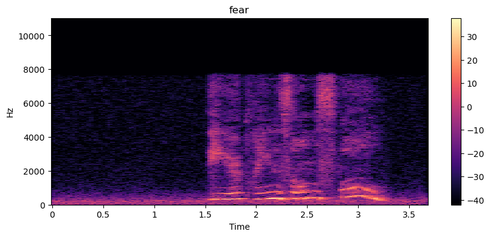

```python
emotion= 'fear'
path= np.array(df['Speech'][df['Label']== emotion])[0]
data, sampling_rate= librosa.load(path)
display_wave(data, sampling_rate, emotion)
display_spectrogram(data, sampling_rate, emotion)
Audio(path)
```

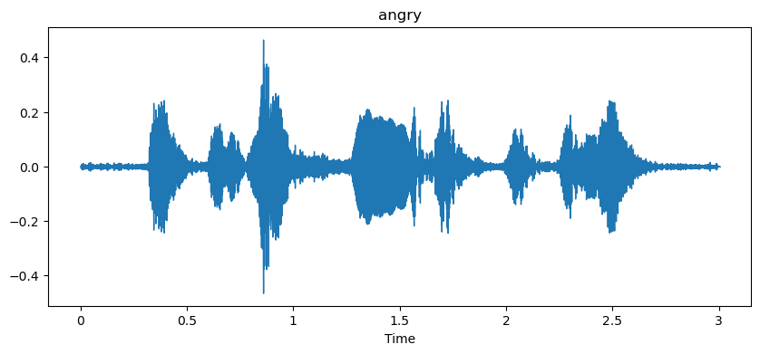

[interactive chart not shown]

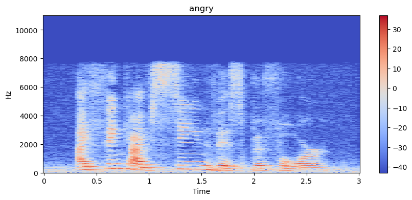

```python
emotion= 'angry'
path= np.array(df['Speech'][df['Label']==emotion])[1]
data, sampling_rate= librosa.load(path)
display_wave(data, sampling_rate, emotion)
display_spectrogram(data, sampling_rate, emotion)
Audio(path)
```

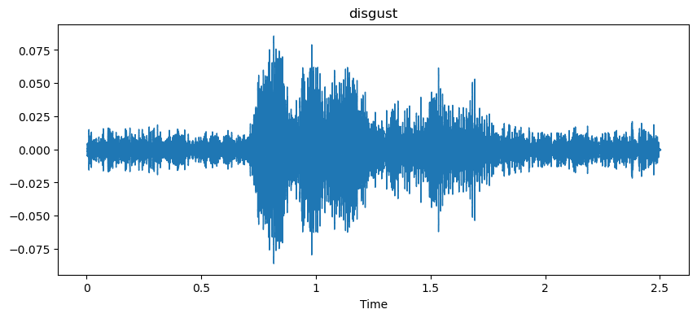

[interactive chart not shown]

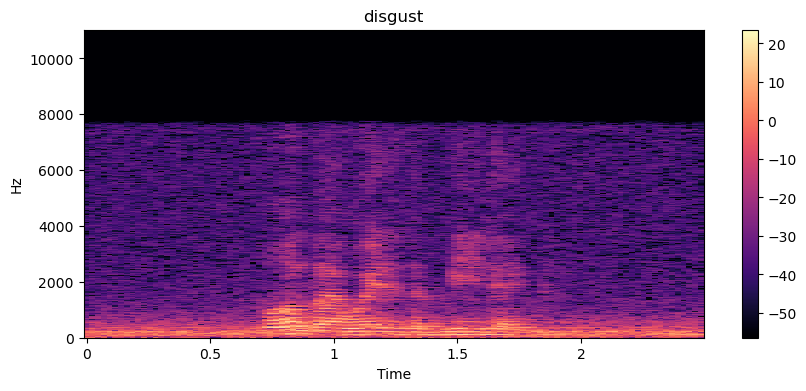

```python
emotion= 'disgust'
path= np.array(df['Speech'][df['Label']==emotion])[1]
data, sampling_rate= librosa.load(path)
display_wave(data, sampling_rate, emotion)
display_spectrogram(data, sampling_rate, emotion)
Audio(path)
```

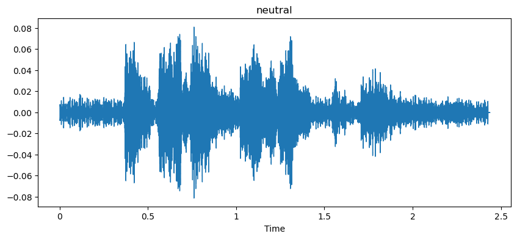

[interactive chart not shown]

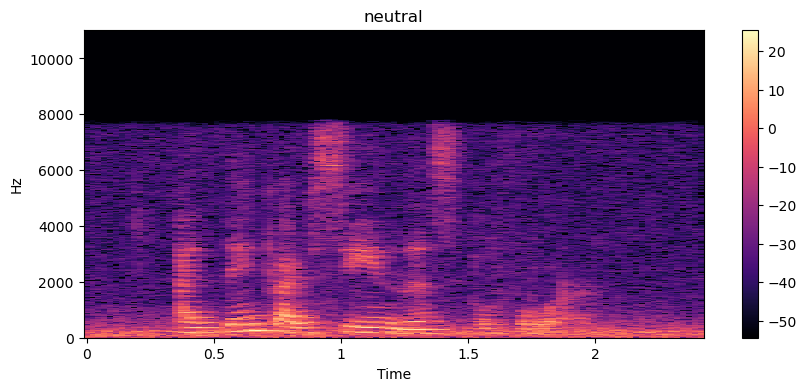

```python
emotion= 'neutral'
path= np.array(df['Speech'][df['Label']==emotion])[1]
data, sampling_rate= librosa.load(path)
display_wave(data, sampling_rate, emotion)
display_spectrogram(data, sampling_rate, emotion)
Audio(path)
```

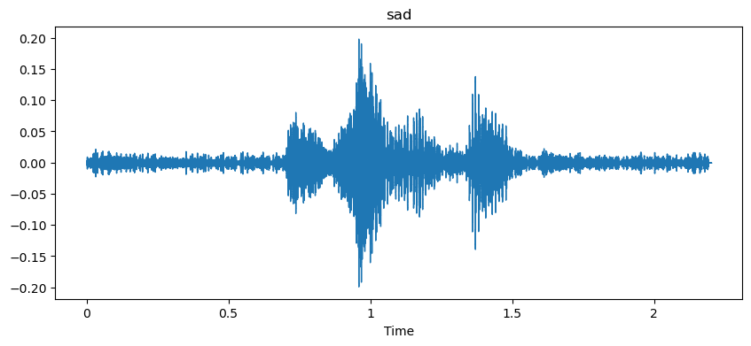

[interactive chart not shown]

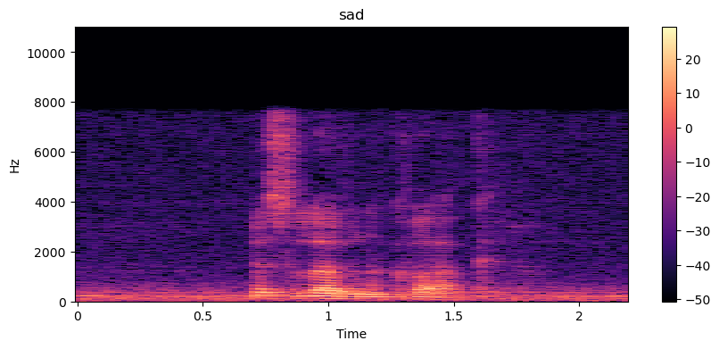

```python
emotion= 'sad'
path= np.array(df['Speech'][df['Label']==emotion])[1]
data, sampling_rate= librosa.load(path)
display_wave(data, sampling_rate, emotion)
display_spectrogram(data, sampling_rate, emotion)
Audio(path)
```

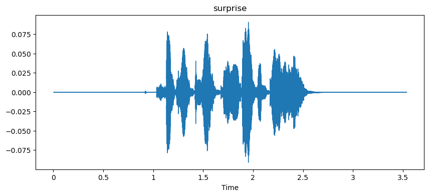

[interactive chart not shown]

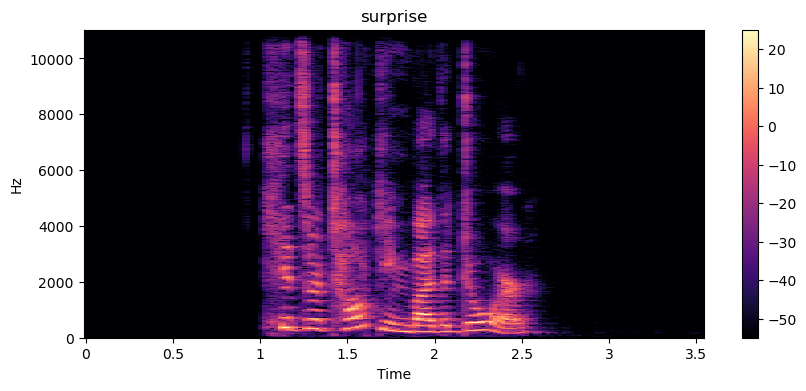

```python
emotion= 'surprise'
path= np.array(df['Speech'][df['Label']==emotion])[1]
data, sampling_rate= librosa.load(path)
display_wave(data, sampling_rate, emotion)
display_spectrogram(data, sampling_rate, emotion)
Audio(path)
```

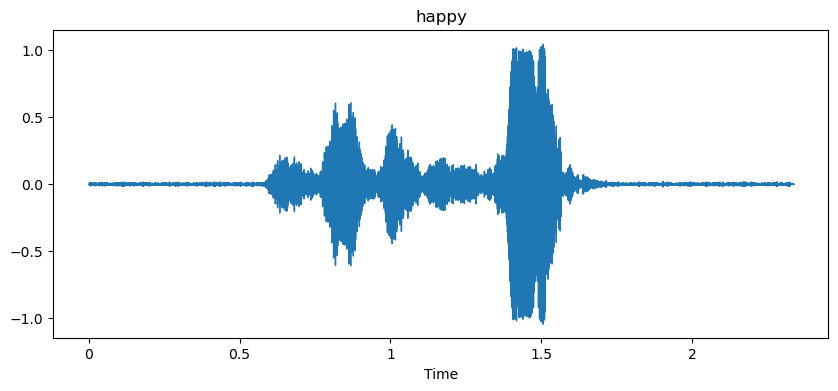

[interactive chart not shown]

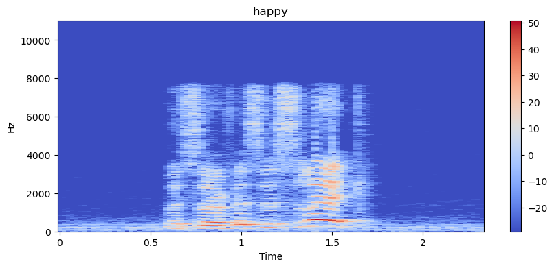

```python
emotion= 'happy'
path= np.array(df['Speech'][df['Label']==emotion])[1]
data, sampling_rate= librosa.load(path)
display_wave(data, sampling_rate, emotion)
display_spectrogram(data, sampling_rate, emotion)
Audio(path)
```

## Data Augmentation

Here, we could have done Data Augmentation, a technique that is commonly used in machine learning and audio processing to improve the diversity and unpredictability of training data. The enhanced data provides fluctuations in speed or length by using transformations such as time-stretching, which can assist improve the generalization and resilience of the models trained on the data. Data augmentation contributes to the creation of a more complete and representative dataset, avoiding overfitting and improving the model's capacity to handle diverse variances in real-world circumstances. Due to hardware issues, this process would take too long to run, but I will still explain what could have been done.

In our case I could have stretched the audio files to improve the diversity of the training data:

1. The augment_data function accepts two parameters: y (audio waveform) and sr (sampling rate).
2. The data augmentation technique utilized in this code piece is time-stretching.
3. Time-stretching is a method of increasing the speed of an audio source without changing its pitch. It may be used to accelerate or decelerate the audio.
4. The librosa.effects.time_stretch function is used to time-stretch the audio waveform y input. The rate parameter defines the stretching factor, with a value less than one slowing down and a value larger than one speeding up the audio. The rate is set to 0.8 in this example, which slows down the audio by 20%.

The function then returns the time-stretched audio waveform y_stretch.

```python
def augment_data(y, sr):
    # Time-stretching
    y_stretch = librosa.effects.time_stretch(y, rate=0.8)  # rate > 1 speeds up, rate < 1 slows down

    return y_stretch
```

### Mel-frequency Cepstral Coefficients (MFCCs) are extracted from an audio file using the extract_mfcc function. Let's dissect the code and figure out what it does:

What we are doing here is using mel spectrograms(their cepstral coeffiecients). Why they are better than normal spectrograms is because humans do not perceive frequencies in a linear fashion. We are more sensitive to differences in lower frequencies than changes in higher frequencies. Therefore a better scale to visualise the spectrogram is a mel scale.

It is a scale of pitches, such that each unit is judged by listeners to be equal in pitch distance from the next.

##### 1. The method extract_mfcc accepts an audio_path parameter, which specifies the path to an audio file.

##### 2. The audio file is loaded using librosa.load with the sr=None option in this code snippet, which loads the audio file without resampling and returns the waveform y and sampling rate sr.

##### 3. The augment_data function or other strategies for introducing changes in the data can be used to the audio waveform, which was commented out in this code.

##### 4. librosa.feature.mfcc is then used to extract the MFCC features from the original audio waveform. The n_mfcc=40 option states that we want to extract 40 MFCC coefficients.

##### 5. The code checks the length of the extracted MFCC features. If the length is less than max_pad_len (400 in this case), the code pads the features with zeros to match the maximum length using np.pad. If the length exceeds max_pad_len, the code truncates the features to max_pad_len.

##### 6. Finally, the function returns the extracted MFCC features as a numpy array mfcc.

Overall, this code extracts MFCC features from an audio file and ensures that the extracted features have a consistent length (max_pad_len) by either padding or truncating. The MFCC features can be used as input to machine learning models for audio classification or other audio-related tasks.

```python
max_pad_len = 400
def extract_mfcc(audio_path):
    y, sr = librosa.load(audio_path, sr=None, mono=True)

    # Apply data augmentation
    #y_stretch= augment_data(y, sr)

    # Extract MFCCs for original, time-stretched and noise-added signals
    mfcc = librosa.feature.mfcc(y=y, sr=sr, n_mfcc=40)
    #mfcc_stretch = librosa.feature.mfcc(y=y_stretch, sr=sr, n_mfcc=40)

    # If maximum length exceeds mfcc lengths then pad the remaining ones
    if (max_pad_len > mfcc.shape[1]):
        pad_width = max_pad_len - mfcc.shape[1]
        mfcc = np.pad(mfcc, pad_width=((0, 0), (0, pad_width)), mode='constant')

    # Else cutoff the remaining parts
    else:
        mfcc = mfcc[:, :max_pad_len]

    # Match the length of the time-stretched MFCC features with the original ones
#     if (mfcc.shape[1] > mfcc_stretch.shape[1]):
#         pad_width = mfcc.shape[1] - mfcc_stretch.shape[1]
#         mfcc_stretch = np.pad(mfcc_stretch, pad_width=((0, 0), (0, pad_width)), mode='constant')
#     else:
#          mfcc_stretch = mfcc_stretch[:, :mfcc.shape[1]]


    # Combine the MFCC features into a single array
    #mfcc_combined = np.concatenate((mfcc, mfcc_stretch), axis=0)

    return mfcc
    #return mfcc_combined
```

#### Applying the extract_mfcc function to each element in the 'Speech' column of the DataFrame df. It extracts the MFCC features from audio files specified by the file paths in the 'Speech' column and stores the resulting MFCC features in the X_mfcc variable.

```python
X_mfcc = df['Speech'].apply(extract_mfcc)
```

#### The shape (15538,) indicates that the variable X_mfcc has a one-dimensional array with a length of 15,538. This suggests that the MFCC features have been extracted from 15,538 audio files, and each audio file is represented by a one-dimensional array of MFCC coefficients.

```python
X_mfcc.shape
```

```
(15538,)
```

#### X = [x for x in X_mfcc] loops over the X_mfcc array, transforming each element to a Python list and saving it in the variable X. X = np.array(X) then transforms the list X to a numpy array.

The resultant X array has the dimensions (15538, 40, 400). This indicates that the dataset has 15,538 samples. Each sample is a two-dimensional array of MFCC coefficients that represents a single audio file. The first size 40 dimension reflects the number of MFCC coefficients extracted per audio file, while the second size 400 dimension represents the maximum length of the MFCC features after padding or truncation.

##### In summary, the code converts the extracted MFCC features (X_mfcc) from a list format to a numpy array (X) and reshapes it into a three-dimensional array, where the first dimension represents the number of samples, the second dimension the number of MFCC coefficients, and the third dimension the length of each MFCC feature.

Converting the list of MFCC features to a numpy array enhances the efficiency and versatility of data handling, preparing the data for subsequent analysis and modeling tasks.

```python
X= [x for x in X_mfcc]
X=np.array(X)
X.shape
```

```
(15538, 40, 400)
```

#### [StandardScaler().fit_transform(x.reshape(40, 400)) for x in X] carries out two procedures on the MFCC feature X:

1. X's MFCC features are reshaped from a two-dimensional array of form (40, 400) to the original shape (40, 400). The reshape approach is used, with 40 representing the number of MFCC coefficients and 400 representing the length of each MFCC feature. This is necessary because machine learning models typically expect input data to have consistent dimensions
2. Standardization: The reshaped MFCC features are then standardized using scikit-learn's StandardScaler. Standardization is the process of altering data to have a zero mean and unit variance. This is accomplished by removing the mean of each characteristic and dividing by its standard deviation. It Ensures that each feature has a consistent scale and distribution. This prevents certain characteristics from dominating the learning process and guarantees that the model can learn equally from all features.

```python
X = np.array([StandardScaler().fit_transform(x.reshape(40, 400)) for x in X])
```

#### Here, we are adding an extra dimension to the end of the array X to increase its dimensions. This is accomplished through the usage of the np.expand_dims() method.

By setting axis=-1, the additional dimension is inserted as the array's last dimension. As a result, the form of X will change to (15538, 40, 400, 1).

##### Why we are doing this

Since, we are going us neural networks, specifically CNN, it requires input data to have a 4-dimensional shape (batch_size, height, width, channels), where channels refers to the number of input channels.

```python
X=np.expand_dims(X, -1)
X.shape
```

```
(15538, 40, 400, 1)
```

#### Using the OneHotEncoder class to convert categorical labels in the 'Label' column into a binary one-hot encoded representation.

```python
from sklearn.preprocessing import OneHotEncoder

oh_enc= OneHotEncoder()
y=oh_enc.fit_transform(df[['Label']])
```

```python
y.toarray()
```

```
array([[1., 0., 0., ..., 0., 0., 0.],
       [1., 0., 0., ..., 0., 0., 0.],
       [0., 0., 0., ..., 1., 0., 0.],
       ...,
       [0., 0., 0., ..., 0., 1., 0.],
       [0., 0., 0., ..., 0., 1., 0.],
       [0., 0., 0., ..., 0., 1., 0.]])
```

#### Converting the encoded labels y from a sparse matrix format to a dense array format.

```python
y= y.toarray()
```

#### Here, 15538 is the number of audio files and 7 stands for the number of labels we have.

```python
y.shape
```

```
(15538, 7)
```

```python
import tensorflow as tf
from sklearn.model_selection import KFold
from sklearn.model_selection import StratifiedKFold
from keras.models import Sequential
from keras.layers import Dense, Dropout, Flatten, Conv2D, MaxPooling2D, LSTM, TimeDistributed
from keras.callbacks import EarlyStopping
```

In this case as we have used "num_folds"=5, what kfold basically does is, it divides the dataset into 5 parts, and runs the model 5 times with each part being the test/ validation set once.

##### 1. acc_per_fold = [] and loss_per_fold = []: These lists will be used to store the accuracy and loss numbers for each fold during cross-validation. This will allow us to track the model's performance on each fold.

##### 2. Inputs = X, and targets = Y: Here, we combine the input features (X) and the associated target labels (y). This guarantees that the input and output data are appropriately aligned during the cross-validation procedure.

##### 3. kfold = KFold(n_splits=num_folds, shuffle=True): We define the K-fold cross-validator object with the required number of folds (num_folds) and enable data shuffling with shuffle=True. This randomizes the order of the samples to avoid bias caused by data ordering.

##### 4. fold_no = 1: This variable keeps track of the current fold number during the cross-validation procedure.

```python
num_folds = 5

# Define per-fold score containers
acc_per_fold = []
loss_per_fold = []

# Merge inputs and targets
inputs = X
targets = y

# Define the K-fold Cross Validator
kfold = KFold(n_splits=num_folds, shuffle=True)

# K-fold Cross Validation model evaluation
fold_no = 1
history_per_fold = []
```

```python
from tensorflow.keras.optimizers import Adam
optimizer = tf.keras.optimizers.legacy.Adam(learning_rate=0.01)
```

##### 1. Train and test in kfold.split(inputs, targets): This loop iterates over the train and test indices produced from the kfold for each fold.split() is a method. Within each fold, we can train the model on one part of the data (train) and evaluate its performance on another subset (test).

##### 2. The variables num_rows, num_columns, num_channels, and num_labels determine the dimensions and number of classes for our input data and target labels.

g. Dense Layer: Finally, we add a Dense layer with num_labels units and a softmax activation function to produce the output probabilities for each class.

##### 5. model.summary(): This statement displays a summary of the model's architecture, including the layers, output shapes, and number of trainable parameters.

```python
from tensorflow.keras.models import Sequential
from tensorflow.keras.layers import Conv2D, MaxPooling2D, LSTM, Dense, Dropout, Flatten

for train, test in kfold.split(inputs, targets):
    num_rows = 40
    num_columns = 400
    num_channels = 1
    num_labels = 7

    model = Sequential()
    model.add(Conv2D(64, (3, 3), activation='relu', input_shape=(num_rows, num_columns, num_channels)))
    model.add(Conv2D(64, (3, 3), activation='relu'))
    model.add(MaxPooling2D((2, 2)))
    model.add(Dropout(0.25))

    model.add(Conv2D(128, (3, 3), activation='relu'))
    model.add(Conv2D(128, (3, 3), activation='relu'))
    model.add(MaxPooling2D((2, 2)))
    model.add(Dropout(0.25))

    model.add(Flatten())
    model.add(Dense(256, activation='relu'))
    model.add(Dropout(0.5))

    model.add(Dense(num_labels, activation='softmax'))

model.compile(loss='categorical_crossentropy', optimizer='adam', metrics=['accuracy'])
model.summary()
```

```
Metal device set to: Apple M2
Model: "sequential_4"
_________________________________________________________________
 Layer (type)                Output Shape              Param #
=================================================================
 conv2d_16 (Conv2D)          (None, 38, 398, 64)       640

 conv2d_17 (Conv2D)          (None, 36, 396, 64)       36928

 max_pooling2d_8 (MaxPooling  (None, 18, 198, 64)      0
 2D)

 dropout_12 (Dropout)        (None, 18, 198, 64)       0

 conv2d_18 (Conv2D)          (None, 16, 196, 128)      73856

 conv2d_19 (Conv2D)          (None, 14, 194, 128)      147584

 max_pooling2d_9 (MaxPooling  (None, 7, 97, 128)       0
 2D)

 dropout_13 (Dropout)        (None, 7, 97, 128)        0

 flatten_4 (Flatten)         (None, 86912)             0

 dense_8 (Dense)             (None, 256)               22249728

 dropout_14 (Dropout)        (None, 256)               0

 dense_9 (Dense)             (None, 7)                 1799

=================================================================
Total params: 22,510,535
Trainable params: 22,510,535
Non-trainable params: 0
_________________________________________________________________
```

monitor='val_loss': To determine when to cease training, we want to monitor the validation loss. The validation loss, as opposed to the training loss, is a measure of how well the model performs on the validation set.

patience=5: The patience parameter specifies how many epochs to wait before terminating training if the observed quantity (in this case, validation loss) does not improve. Training will be terminated early if the validation loss does not improve for 5 consecutive epochs.

```python
early_stopping = EarlyStopping(monitor='val_loss', patience=5)
```

#### After training, we used the evaluate function to evaluate the model on the test data for the current fold. The evaluate function delivers the test data's loss and accuracy metrics. The accuracy score (multiplied by 100) and loss score are appended to the acc_per_fold and loss_per_fold lists, respectively.

#### For the following iteration of training and evaluation, we increment the fold number to go to the next fold.

#### Finally, we print the folds' scores and average metrics.

#### We may examine the model's performance and collect average scores to measure its generalization potential by repeating this process for each fold.

```python
# Fit data to model
history = model.fit(inputs[train], targets[train], batch_size=256, epochs=10, validation_split=0.2)
history_per_fold.append(history)

# Generate generalization metrics
scores = model.evaluate(inputs[test], targets[test], verbose=0)
print(f'Score for fold {fold_no}: {model.metrics_names[0]} of {scores[0]}; {model.metrics_names[1]} of {scores[1]*100}%')
acc_per_fold.append(scores[1] * 100)
loss_per_fold.append(scores[0])

# Increase fold number
fold_no = fold_no + 1

# == Provide average scores ==
print('------------------------------------------------------------------------')
print('Score per fold')
for i in range(0, len(acc_per_fold)):
    print('------------------------------------------------------------------------')
    print(f'> Fold {i+1} - Loss: {loss_per_fold[i]} - Accuracy: {acc_per_fold[i]}%')

print('------------------------------------------------------------------------')
print('Average scores for all folds:')
print(f'> Accuracy: {np.mean(acc_per_fold)} (+- {np.std(acc_per_fold)})')
print(f'> Loss: {np.mean(loss_per_fold)}')
print('------------------------------------------------------------------------')
```

[output not shown]

### From these reslults we can conclude that:

Overall, working with devices with better hardware specifications, we can perform these processes and improve the effieciency of our model.

### Lets visualize how the model trains itself through out the 5 folds.

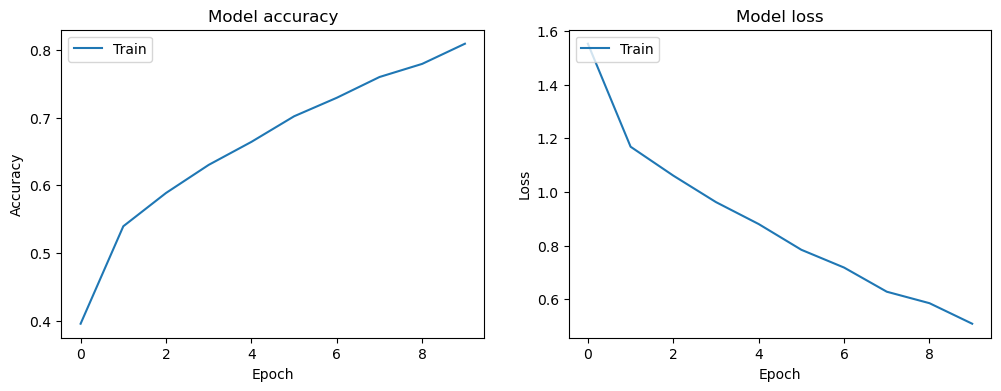

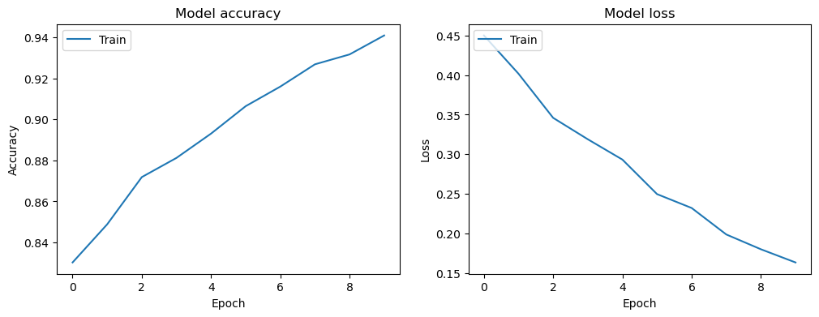

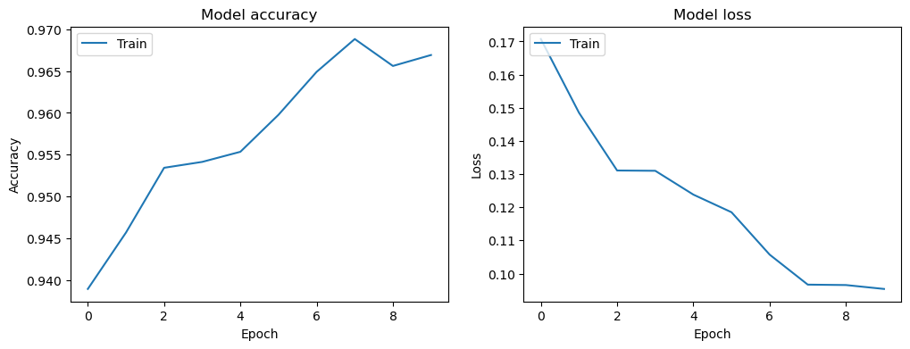

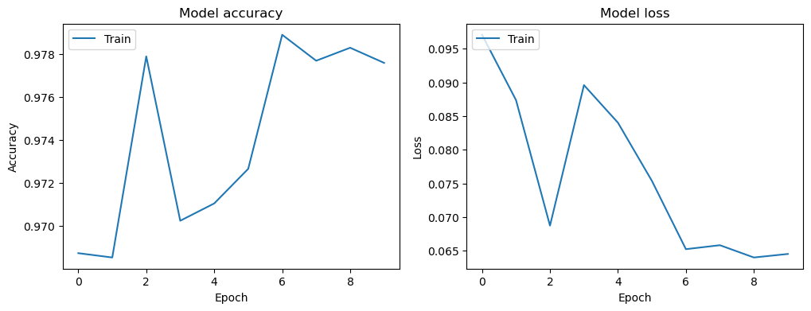

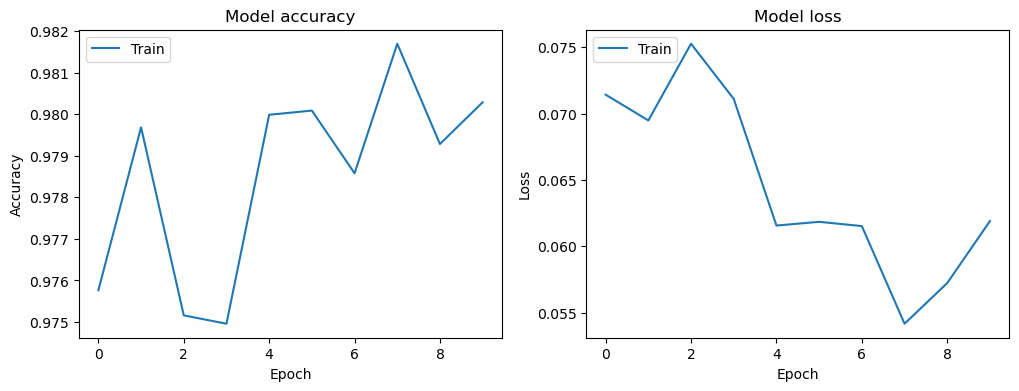

```python
for i, history in enumerate(history_per_fold, 1):
    plt.figure(figsize=(12, 4))

    plt.subplot(1, 2, 1)
    plt.plot(history.history['accuracy'])
    plt.title('Model accuracy')
    plt.ylabel('Accuracy')
    plt.xlabel('Epoch')
    plt.legend(['Train', 'Test'], loc='upper left')

    plt.subplot(1, 2, 2)
    plt.plot(history.history['loss'])
    plt.title('Model loss')
    plt.ylabel('Loss')
    plt.xlabel('Epoch')
    plt.legend(['Train', 'Test'], loc='upper left')
    plt.show()
```

# References

https://towardsdatascience.com/audio-deep-learning-made-simple-part-1-state-of-the-art-techniques-da1d3dff2504

https://towardsdatascience.com/audio-deep-learning-made-simple-part-2-why-mel-spectrograms-perform-better-aad889a93505

https://towardsdatascience.com/audio-deep-learning-made-simple-part-3-data-preparation-and-augmentation-24c6e1f6b52

https://towardsdatascience.com/audio-deep-learning-made-simple-sound-classification-step-by-step-cebc936bbe5

https://towardsdatascience.com/audio-deep-learning-made-simple-automatic-speech-recognition-asr-how-it-works-716cfce4c706

https://stackoverflow.com/

[figure not shown]